# Raport z analizy danych

2026-01-31

# 1 Wstęp

**Celem niniejszego raportu jest analiza danych dotyczących kredytów. Dane zostały wczytane z pliku `kredyty_new.csv` i zawierają informacje o różnych aspektach kredytów udzielanych klientom.**

Dane pochodzą ze [strony Kaggle](https://www.kaggle.com/) oraz obejmują **45 000 rekordów** i **14 zmiennych**, które opisują zarówno cechy osób ubiegających się o pożyczkę, jak i parametry samych pożyczek. Zmienną docelową jest **`loan_status`**, określająca decyzję kredytową:  
`1` – pożyczka zatwierdzona,  
`0` – pożyczka odrzucona.

Zbiór danych zawiera informacje takie jak wiek, płeć, poziom wykształcenia, roczny dochód, doświadczenie zawodowe, status mieszkaniowy, kwotę i cel pożyczki, oprocentowanie, długość historii kredytowej oraz informację o wcześniejszych zaległościach kredytowych. Dane mają charakter **syntetyczny**, czyli zostały wygenerowane sztucznie, ale w sposób odzwierciedlający rzeczywiste zależności występujące w procesach oceny kredytowej.

Dane te mogą być wykorzystywane w różnych celach analitycznych i badawczych, między innymi:

- **Analiza eksploracyjna (EDA)** – zrozumienie struktury danych, wykrycie wzorców, zależności i rozkładów poszczególnych zmiennych.
- **Klasyfikacja** – budowa modeli predykcyjnych pozwalających przewidywać decyzję kredytową (`loan_status`) dla nowych wnioskodawców.
- **Regresja** – modelowanie zmiennej ciągłej, np. `credit_score`, w celu przewidywania zdolności kredytowej.
- **Analiza jakości danych** – identyfikacja błędów, braków i wartości nielogicznych.
- **Symulacje i testowanie algorytmów** – wykorzystanie danych do testowania różnych podejść do oceny ryzyka kredytowego.

## 1.1 Pytania badawcze

- Które cechy profilu klienta najsilniej korelują z otrzymaniem pozytywnej oceny scoringowej?
- Jakie są główne różnice w profilu (np. dochód, wiek, stan cywilny) między klientami, którzy otrzymali pozytywną ocenę, a tymi, którzy otrzymali negatywną?
- Czy wysokość dochodu jest najważniejszym czynnikiem decydującym o przyznaniu kredytu?
- W jakim stopniu długość posiadanej historii kredytowej wpływa na ostateczny scoring?
- Wraz ze wzrostem wieku spada prawdopodobieństwo otrzymania pożyczki.

## 1.2 Opis zmiennych

Zbiór danych zawiera 14 zmiennych opisujących osoby ubiegające się o pożyczkę oraz cechy samej pożyczki. Poniższa tabela przedstawia zestawienie wszystkich kolumn wraz z krótkim opisem:

| Nazwa zmiennej | Opis | Typ danych |
| --- | --- | --- |
| person_age | Wiek osoby | Liczba zmiennoprzecinkowa |
| person_gender | Płeć osoby | Kategoryczna |
| person_education | Najwyższy poziom wykształcenia | Kategoryczna |
| person_income | Roczny dochód | Liczba zmiennoprzecinkowa |
| person_emp_exp | Lata doświadczenia zawodowego | Liczba całkowita |
| person_home_ownership | Status własności mieszkania (np. wynajem, własność, hipoteka) | Kategoryczna |
| loan_amnt | Wnioskowana kwota pożyczki | Liczba zmiennoprzecinkowa |
| loan_intent | Cel pożyczki | Kategoryczna |
| loan_int_rate | Oprocentowanie pożyczki | Liczba zmiennoprzecinkowa |
| loan_percent_income | Kwota pożyczki jako procent rocznego dochodu | Liczba zmiennoprzecinkowa |
| cb_person_cred_hist_length | Długość historii kredytowej w latach | Liczba zmiennoprzecinkowa |
| credit_score | Wynik punktowy kredytu | Liczba całkowita |
| previous_loan_defaults_on_file | Wskaźnik wcześniejszych zaległości w spłacie pożyczek | Kategoryczna |
| loan_status (target variable) | Status zatwierdzenia pożyczki: 1 = zatwierdzona; 0 = odrzucona | Liczba całkowita |

## 1.3 Wstępna analiza jakości danych

Przegląd danych wskazuje, że mimo dużej liczby obserwacji (45 000 wierszy), zbiór wymaga wstępnego oczyszczenia i ujednolicenia. Poniżej przedstawiono główne obserwacje dotyczące jakości danych:

- **Braki danych (NA):**
  - `person_age` – 1 000 braków,
  - `loan_amnt` – 1 500 braków,
  - `credit_score` – 1 500 braków.  
    Braki te mogą wymagać imputacji lub usunięcia wierszy z niepełnymi wartościami.
- **Wartości nielogiczne i odstające:**
  - `person_age` zawiera wartości do **144 lat**, co jest nierealne,
  - `person_emp_exp` przyjmuje maksymalnie **125 lat doświadczenia**, co również wskazuje na błąd,
  - `person_income` osiąga wartości powyżej **7 200 000 USD**, co znacznie odbiega od pozostałych danych.
- **Rozbieżności kategorialne:**
  - Zmienne tekstowe (`person_gender`, `person_education`, `person_home_ownership`, `loan_intent`) mogą zawierać różne formy zapisu (np. różne wielkości liter), co wymaga standaryzacji.
  - Zmienna `previous_loan_defaults_on_file` powinna zostać przekodowana do formatu binarnego (np. 0/1) w celu ułatwienia modelowania.

Pomimo tych nieścisłości zbiór stanowi dobrą bazę do analizy danych z zakresu **oceny ryzyka kredytowego**, **modelowania decyzji finansowych** oraz **symulacji procesów kredytowych**. W dalszej części raportu dane zostaną poddane czyszczeniu, wizualizacji i analizie statystycznej w celu przygotowania ich do modelowania predykcyjnego.

# 2 Oczyszczenie danych z braków i wartości nielogicznych

## 2.1 Sprawdzenie poprawności danych przed oczyszczeniem

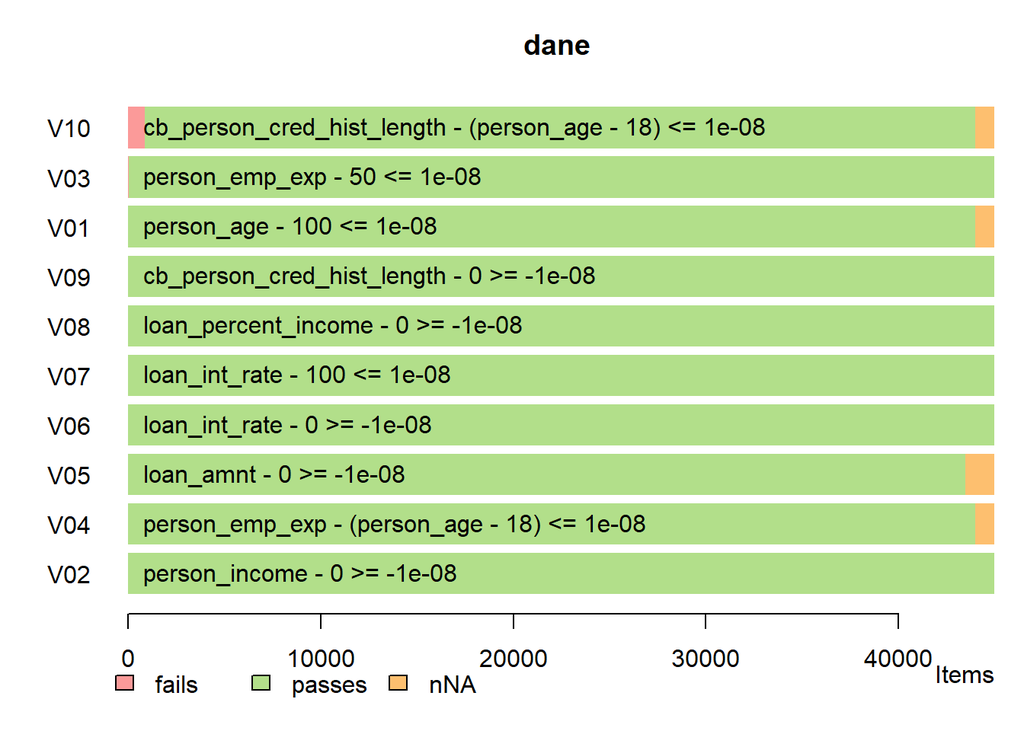

## 2.2 Wizualizacja braków danych

### 2.2.1 Liczba braków na zmienną

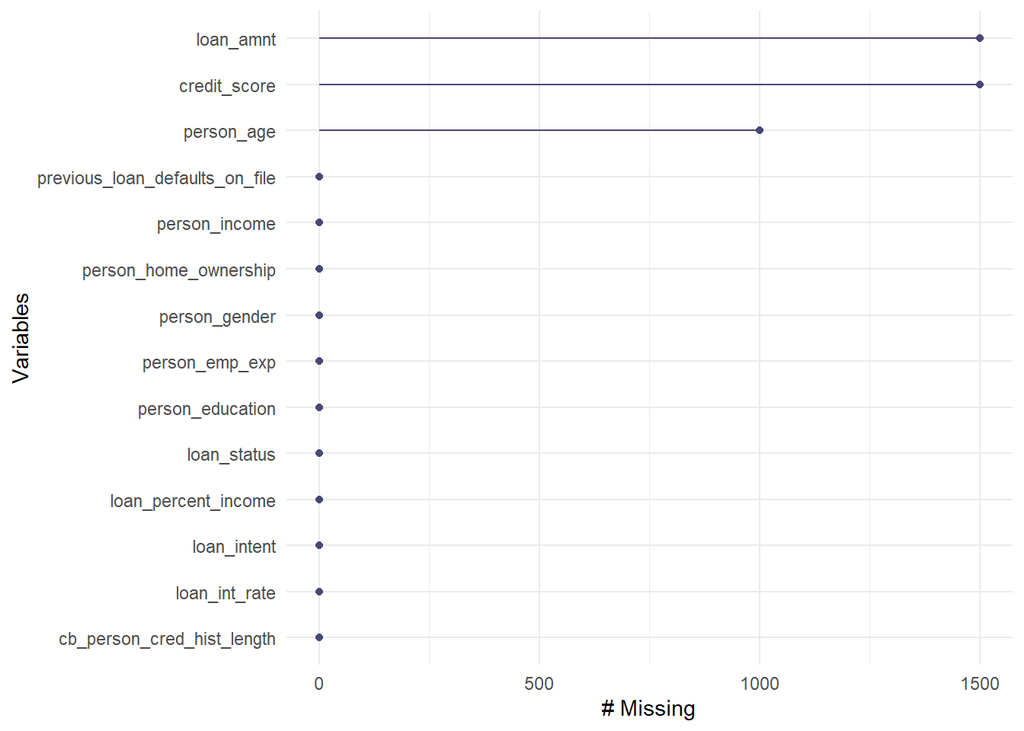

### 2.2.2 Diagram zestawu braków danych

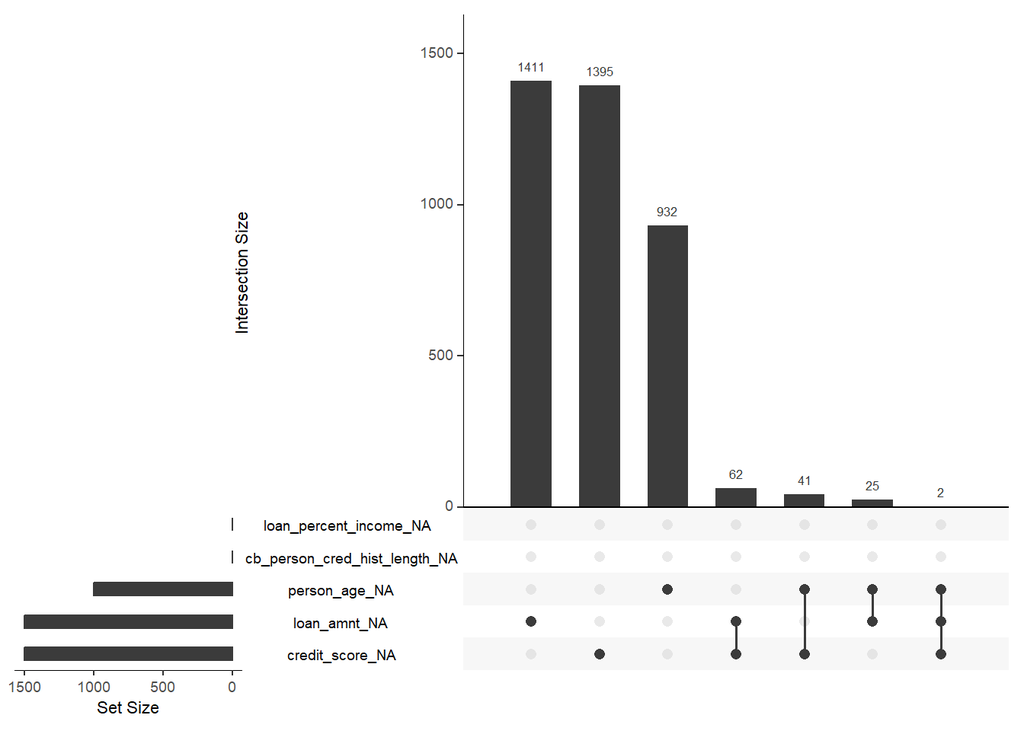

### 2.2.3 Wizualizacja braków danych w formie mapy cieplnej

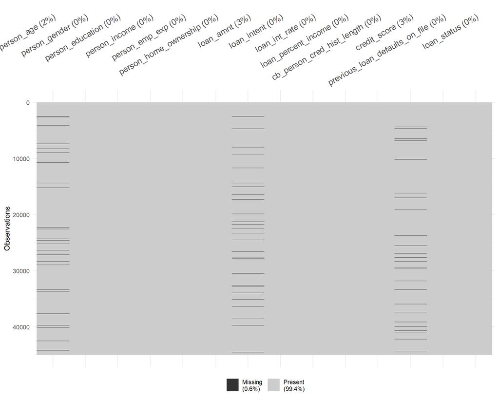

## 2.3 Lokalizacja błędów

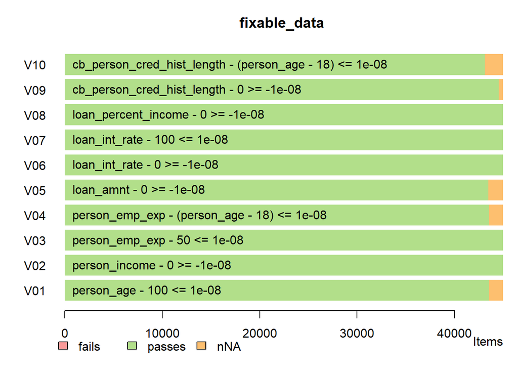

## 2.4 Sprawdzenie poprawności danych po imputacji

| name | items | passes | fails | nNA | error | warning | expression |
| --- | --- | --- | --- | --- | --- | --- | --- |
| V01 | 45000 | 45000 | 0 | 0 | FALSE | FALSE | person_age - 100 <= 1e-08 |
| V02 | 45000 | 45000 | 0 | 0 | FALSE | FALSE | person_income - 0 >= -1e-08 |
| V03 | 45000 | 45000 | 0 | 0 | FALSE | FALSE | person_emp_exp - 50 <= 1e-08 |
| V04 | 45000 | 45000 | 0 | 0 | FALSE | FALSE | person_emp_exp - (person_age - 18) <= 1e-08 |
| V05 | 45000 | 45000 | 0 | 0 | FALSE | FALSE | loan_amnt - 0 >= -1e-08 |
| V06 | 45000 | 45000 | 0 | 0 | FALSE | FALSE | loan_int_rate - 0 >= -1e-08 |
| V07 | 45000 | 45000 | 0 | 0 | FALSE | FALSE | loan_int_rate - 100 <= 1e-08 |
| V08 | 45000 | 45000 | 0 | 0 | FALSE | FALSE | loan_percent_income - 0 >= -1e-08 |
| V09 | 45000 | 45000 | 0 | 0 | FALSE | FALSE | cb_person_cred_hist_length - 0 >= -1e-08 |
| V10 | 45000 | 45000 | 0 | 0 | FALSE | FALSE | cb_person_cred_hist_length - (person_age - 18) <= 1e-08 |

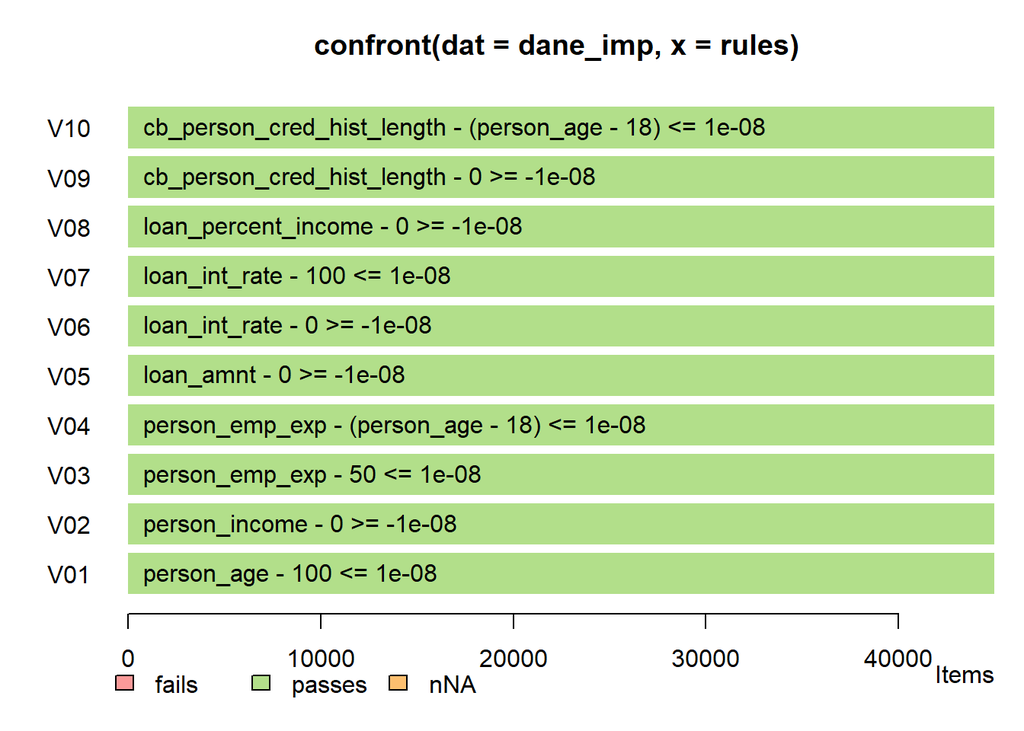

# 3 Analiza danych

## 3.1 Wykres Pareto dla kwoty pożyczki

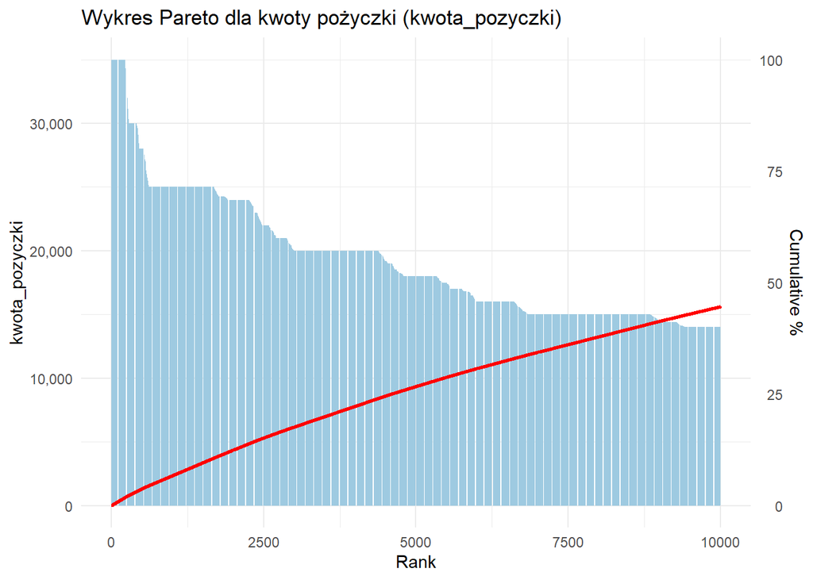

## 3.2 Rozkład kwoty pożyczki w zależności od statusu pożyczki

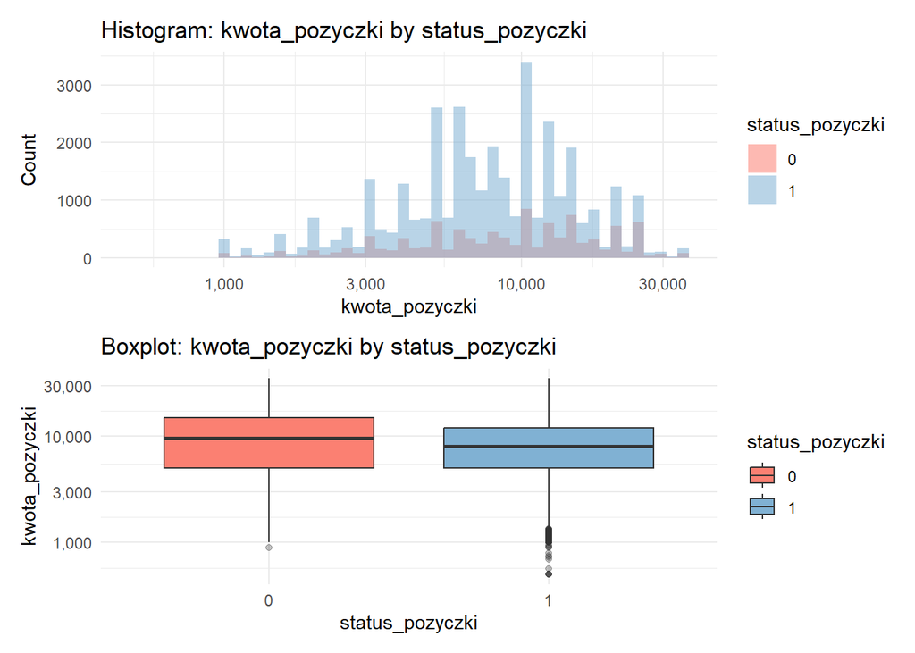

## 3.3 Wykres funkcji dystrybuanty skumulowanej (ECDF) dla kwoty pożyczki

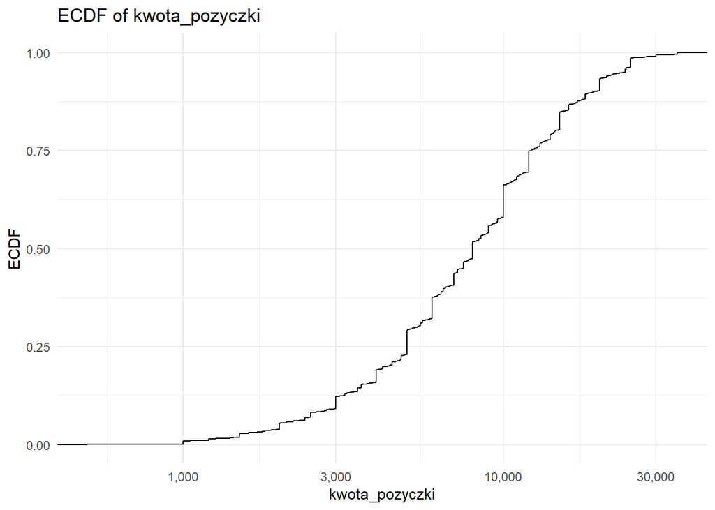

> **Większość pożyczek koncentruje się poniżej 10 000 PLN** (stroma część krzywej), natomiast wartości powyżej 30 000 PLN stanowią jedynie niewielki odsetek obserwacji (krzywa zbliża się do 1 dopiero na końcu).

## 3.4 Mapa korelacji zmiennych numerycznych

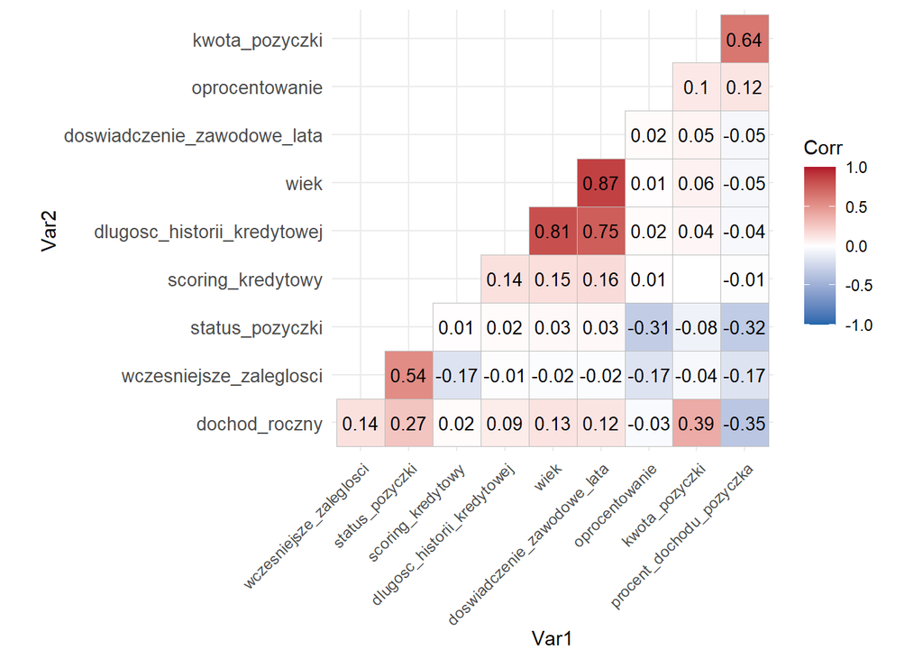

> Mapa korelacji pokazuje zależności pomiędzy zmiennymi numerycznymi w zbiorze danych. Zdecydowana większość korelacji jest słaba lub umiarkowana, a tylko nieliczne pary zmiennych wykazują silniejszy związek.

# 4 Wyniki w odniesieniu do pytań badawczych

## 4.1 Pytanie: Czy wysokość dochodu jest najważniejszym czynnikiem decydującym o przyznaniu kredytu? (sprawdzenie realnego wpływu wysokości dochodu na prawdopodobieństwo udzielenia kredytu)

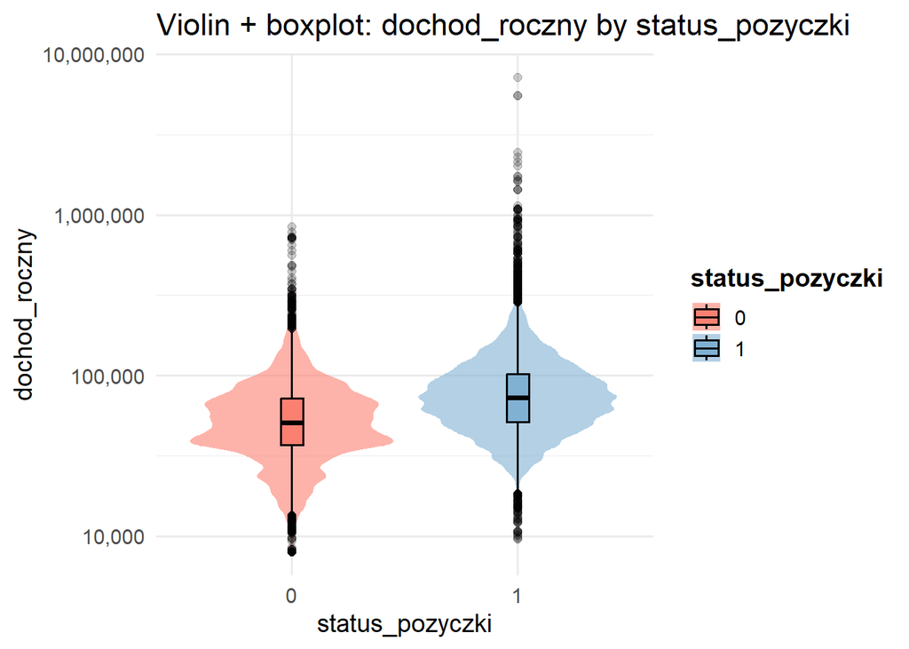

> W większości przypadków dochody osób biorących pożyczki są relatywnie niskie (większość skupiona w dolnym zakresie), ale jest też mała grupa osób z bardzo wysokimi dochodami — wykres pokazuje tę nierównomierność i kilka ekstremalnych wartości.

## 4.2 Pytanie: Jakie są główne różnice w profilu (np. dochód, wiek, stan cywilny) między klientami, którzy otrzymali pozytywną ocenę, a tymi, którzy otrzymali negatywną?

Proporcje poziomów wybranych zmiennych kategorycznych względem statusu pożyczki

| Zmienna | Poziom | Status 0 | Status 1 |
| --- | --- | --- | --- |
| Płeć | Mężczyzna | 22.2% | 77.8% |
| Płeć | Kobieta | 22.2% | 77.8% |
| Wykształcenie | Policealne | 22.0% | 78.0% |
| Wykształcenie | Licencjat | 22.5% | 77.5% |
| Wykształcenie | Doktorat | 22.9% | 77.1% |
| Wykształcenie | Szkoła średnia | 22.3% | 77.7% |
| Wykształcenie | Magister | 21.8% | 78.2% |
| Status mieszkaniowy | Hipoteka | 11.6% | 88.4% |
| Status mieszkaniowy | Inny | 33.3% | 66.7% |
| Status mieszkaniowy | Własność | 7.5% | 92.5% |
| Status mieszkaniowy | Najem | 32.4% | 67.6% |
| Cel pożyczki | Spłata zadłużenia | 30.3% | 69.7% |
| Cel pożyczki | Edukacja | 17.0% | 83.0% |
| Cel pożyczki | Remont | 26.3% | 73.7% |
| Cel pożyczki | Leczenie | 27.8% | 72.2% |
| Cel pożyczki | Wydatki osobiste | 20.1% | 79.9% |
| Cel pożyczki | Inwestycja | 14.4% | 85.6% |

**Czynniki wpływające na udzielnie lub nieudzielenie pożyczki:**

- Dochód osobisty
  - Osoby którym udzielono pożyczki mają średnio wyższe dochody.
- Rodzaj zamieszkania
  - Osoby posiadające własne mieszkanie lub kredyt hipoteczny częściej dostają pożyczki niż osoby wynajmujące mieszkanie lub pozostałe.
- Cel pożyczki
  - Największy odsetek udzielonych pożyczek jest w kategorii venture oraz education.
- Stopa procentowa
  - Pożyczki, które zostały udzielone, mają średnio niższe oprocentowanie.
- Relacja pożyczki do dochodu
- W przypadku udzielonych pożyczek wartość pożyczki stanowi przeciętnie mniejszy odsetek dochodu klienta.

## 4.3 Pytanie: Czy wysokość dochodu jest najważniejszym czynnikiem decydującym o przyznaniu kredytu?

*Do oszacowania wpływu zmiennych zastosujemy regresję logistyczną.*

Na podstawie poprzedniej analizy bierzemy pod uwagę czynniki wpływające na udzielenie lub nieudzielenie pożyczki (uwzględniamy tylko kolumny numeryczne do policzenia korelacji).

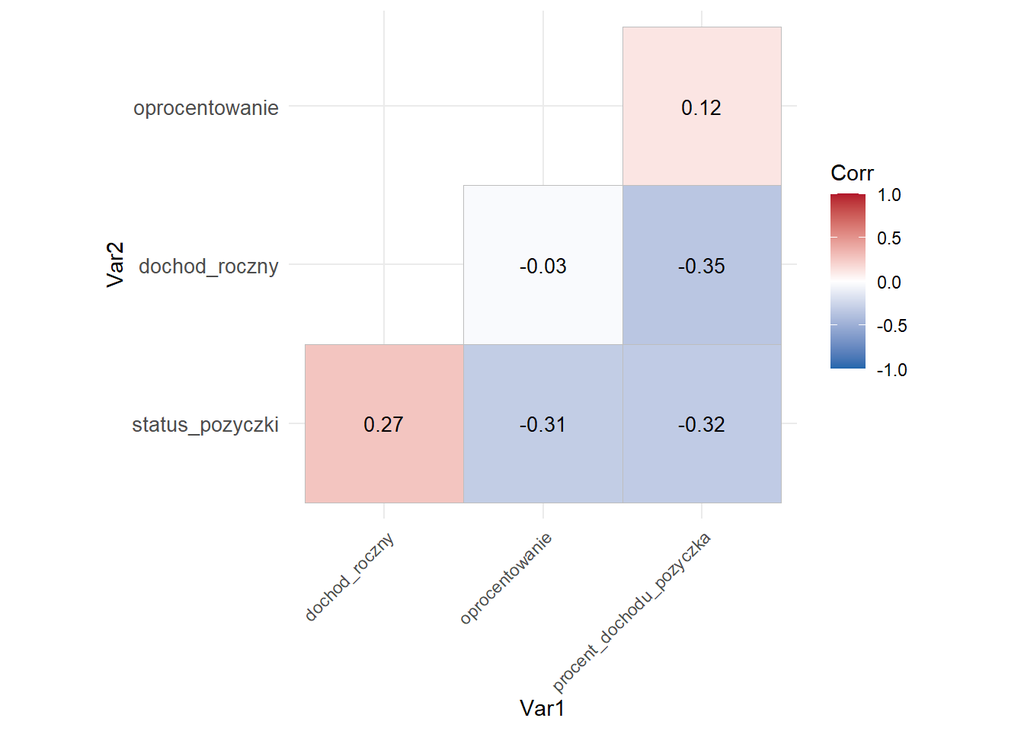

Model logitowy: tylko procent_dochodu_pozyczka

| term | estimate | std.error | statistic | p.value |
| --- | --- | --- | --- | --- |
| (Intercept) | 2.894055 | 0.027229 | 106.28754 | 0 |
| procent_dochodu_pozyczka | -10.414450 | 0.142722 | -72.97023 | 0 |

Ilorazy szans dla wzrostu procentu dochodu pożyczki o 1 pp oraz 10 pp

|  | Iloraz.szans.przy.wzroście.o.1pp | Iloraz.szans.przy.wzroście.o.10pp |
| --- | --- | --- |
| procent_dochodu_pozyczka | 0.901 | 0.353 |

> Im większy udział raty w dochodzie, tym niższe prawdopodobieństwo otrzymania pożyczki; każdy wzrost o 1 punkt procentowy zmniejsza szanse o około 10% (OR≈0.901), o 10 punktów procentowych o około 65% (OR≈0.353), a przy 40% udziału przewidywane prawdopodobieństwo wynosi około 22%.

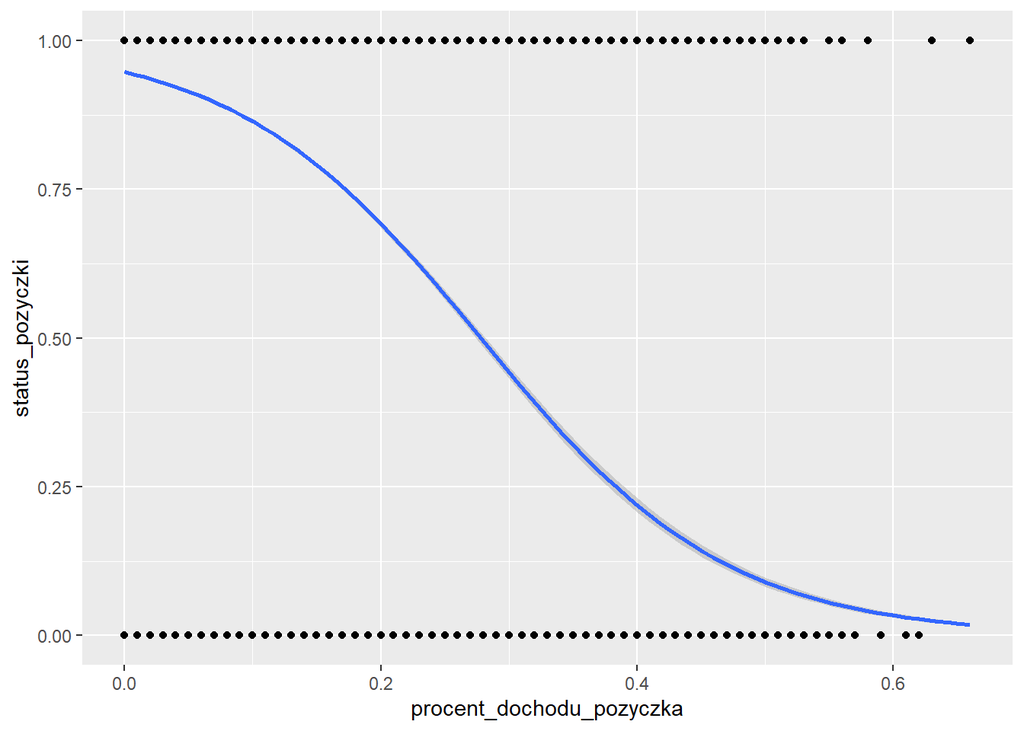

> Duże znaczenie ma relacja pożyczki do dochodu, czyli to, jaką część rocznych zarobków stanowi wnioskowana kwota. Im mniejszy udział pożyczki w dochodzie, tym większe prawdopodobieństwo jej akceptacji.

## 4.4 Hipoteza: Wraz ze wzrostem wieku spada prawdopodobieństwo otrzymania pożyczki.

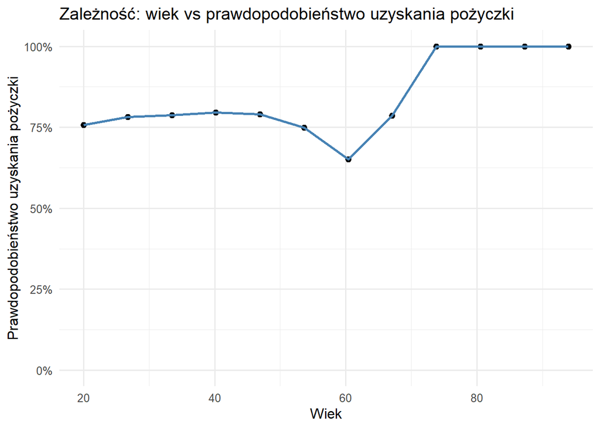

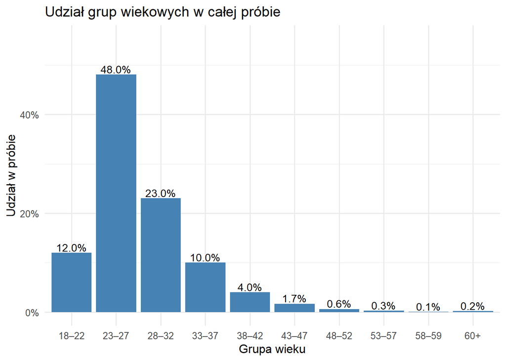

# 5 Analiza opisowa

## 5.1 Statystyki opisowe dla numerycznych zmiennych według statusu pożyczki

Analiza opisowa wg status_pozyczki (z testami)

| Dependent: status_pozyczki |  | Odrzucona | Zatwierdzona | p |
| --- | --- | --- | --- | --- |
| wiek | Mean (SD) | 27.6 (6.0) | 27.8 (5.9) | <0.001 |
| dochod_roczny | Mean (SD) | 59886.1 (45338.3) | 86157.0 (87035.2) | <0.001 |
| doswiadczenie_zawodowe_lata | Mean (SD) | 5.1 (5.9) | 5.4 (5.9) | <0.001 |
| kwota_pozyczki | Mean (SD) | 10797.7 (7097.7) | 9227.7 (6030.8) | <0.001 |
| oprocentowanie | Mean (SD) | 12.9 (3.1) | 10.5 (2.7) | <0.001 |
| procent_dochodu_pozyczka | Mean (SD) | 0.2 (0.1) | 0.1 (0.1) | <0.001 |
| dlugosc_historii_kredytowej | Mean (SD) | 5.7 (3.9) | 5.8 (3.8) | 0.002 |
| scoring_kredytowy | Mean (SD) | 631.8 (50.4) | 632.9 (50.5) | 0.059 |

## 5.2 Statystyki opisowe dla kategorycznych zmiennych według statusu pożyczki

Analiza opisowa wg status_pozyczki (z testami) — zmienne kategoryczne (nazwy po polsku)

| Dependent: status_pozyczki |  | Odrzucona | Zatwierdzona | p |
| --- | --- | --- | --- | --- |
| plec | Kobieta | 4485 (44.9) | 15674 (44.8) | 0.914 |
|  | Mężczyzna | 5515 (55.1) | 19326 (55.2) |  |
| wyksztalcenie | Policealne | 2650 (26.5) | 9378 (26.8) | 0.733 |
|  | Licencjat | 3018 (30.2) | 10381 (29.7) |  |
|  | Doktorat | 142 (1.4) | 479 (1.4) |  |
|  | Szkoła średnia | 2671 (26.7) | 9301 (26.6) |  |
|  | Magister | 1519 (15.2) | 5461 (15.6) |  |
| status_mieszkaniowy | Hipoteka | 2144 (21.4) | 16345 (46.7) | <0.001 |
|  | Inny | 39 (0.4) | 78 (0.2) |  |
|  | Własność | 222 (2.2) | 2729 (7.8) |  |
|  | Najem | 7595 (76.0) | 15848 (45.3) |  |
| cel_pozyczki | Spłata zadłużenia | 2163 (21.6) | 4982 (14.2) | <0.001 |
|  | Edukacja | 1552 (15.5) | 7601 (21.7) |  |
|  | Remont | 1258 (12.6) | 3525 (10.1) |  |
|  | Leczenie | 2378 (23.8) | 6170 (17.6) |  |
|  | Wydatki osobiste | 1521 (15.2) | 6031 (17.2) |  |
|  | Inwestycja | 1128 (11.3) | 6691 (19.1) |  |
| wczesniejsze_zaleglosci | Nie | 10000 (100.0) | 12142 (34.7) | <0.001 |
|  | Tak | 0 (0.0) | 22858 (65.3) |  |
|  | (Missing) | 0 (0.0) | 0 (0.0) |  |

## 5.3 Statystyki opisowe kluczowych zmiennych według statusu pożyczki

| Statystyka | Kwota pożyczki [PLN] — Odrzucona | Kwota pożyczki [PLN] — Zatwierdzona | Dochód roczny [PLN] — Odrzucona | Dochód roczny [PLN] — Zatwierdzona | Pożyczka / dochód [%] — Odrzucona | Pożyczka / dochód [%] — Zatwierdzona | Oprocentowanie [%] — Odrzucona | Oprocentowanie [%] — Zatwierdzona | Credit score — Odrzucona | Credit score — Zatwierdzona | Wiek [lata] — Odrzucona | Wiek [lata] — Zatwierdzona |
| --- | --- | --- | --- | --- | --- | --- | --- | --- | --- | --- | --- | --- |
| Min | 900 | 500 | 8000 | 9595 | 0 | 0 | 5.42 | 5.42 | 431 | 390 | 20 | 20 |
| Max | 35000 | 35000 | 845636 | 7200766 | 0.62 | 0.66 | 20 | 20 | 767 | 850 | 70 | 94 |
| Kwartyl dolny | 5000 | 5000 | 36841.75 | 51476.5 | 0.11 | 0.07 | 10.99 | 7.9 | 601 | 602 | 23 | 24 |
| Mediana | 9600 | 8000 | 50629 | 72928 | 0.2 | 0.11 | 12.98 | 10.85 | 639 | 640 | 26 | 26 |
| Kwartyl górny | 15000 | 12000 | 71888.25 | 101994 | 0.28 | 0.16 | 15.23 | 12.29 | 669 | 670 | 30 | 30 |
| Średnia | 10797.66 | 9227.73 | 59886.1 | 86157.04 | 0.2 | 0.12 | 12.86 | 10.48 | 631.78 | 632.86 | 27.58 | 27.84 |
| Odch. std. | 7097.74 | 6030.81 | 45338.32 | 87035.24 | 0.11 | 0.07 | 3.07 | 2.73 | 50.36 | 50.49 | 5.95 | 5.9 |
| IQR | 10000 | 7000 | 35046.5 | 50517.5 | 0.17 | 0.09 | 4.24 | 4.39 | 68 | 68 | 7 | 6 |
| Odchylenie ćwiartkowe | 5000 | 3500 | 17523.25 | 25258.75 | 0.09 | 0.04 | 2.12 | 2.19 | 34 | 34 | 3.5 | 3 |
| Odch. std. w % | 65.73 | 65.36 | 75.71 | 101.02 | 52.59 | 58.58 | 23.87 | 26.07 | 7.97 | 7.98 | 21.59 | 21.19 |

[output cut: 3 more lines]

# 6 Wnioskowanie statystyczne

## 6.1 Test t Studenta — porównanie średnich pomiędzy grupami

Poniżej porównujemy średnie wybranych zmiennych numerycznych pomiędzy osobami, którym przyznano pożyczkę (`status_pozyczki = 1`) a tymi, którym odmówiono (`status_pozyczki = 0`). Dla każdej zmiennej numerycznej wykonujemy test t Studenta.

Test t Studenta (Welcha) — porównanie średnich według status_pozyczki

| Zmienna | Kod | Średnia: Odrzucona | Średnia: Zatwierdzona | Statystyka t | Wartość p | Wynik |
| --- | --- | --- | --- | --- | --- | --- |
| Wiek | wiek | 27.577 | 27.841 | -3.913 | <0.001 | istotna |
| Dochód roczny | dochod_roczny | 59886.097 | 86157.041 | -40.441 | <0.001 | istotna |
| Doświadczenie zawodowe (lata) | doswiadczenie_zawodowe_lata | 5.149 | 5.414 | -3.993 | <0.001 | istotna |
| Kwota pożyczki | kwota_pozyczki | 10797.663 | 9227.727 | 20.139 | <0.001 | istotna |
| Oprocentowanie (%) | oprocentowanie | 12.857 | 10.478 | 70.003 | <0.001 | istotna |
| Pożyczka/dochod (%) | procent_dochodu_pozyczka | 0.203 | 0.122 | 71.365 | <0.001 | istotna |
| Długość historii kredytowej [lata] | dlugosc_historii_kredytowej | 5.698 | 5.836 | -3.125 | 0.002 | istotna |
| Scoring kredytowy | scoring_kredytowy | 631.783 | 632.865 | -1.894 | 0.058 | nieistotna |

> Na podstawie wyników testu t Studenta można stwierdzić, że **pożyczkę najłatwiej uzyskują osoby, które charakteryzują się wyższym rocznym dochodem, wnioskują o niższą kwotę pożyczki oraz deklarują niższe oprocentowanie i stosunkowo mniejsze obciążenie dochodu ratą kredytową.** Innymi słowy, banki czy instytucje udzielające pożyczek zdecydowanie preferują wnioskodawców o ustabilizowanej sytuacji finansowej, dla których potencjalna ratowna pożyczka nie stanowi zbyt dużej części rocznych zarobków – to minimalizuje ryzyko kredytowe z perspektywy pożyczkodawcy.

## 6.2 Test chi-kwadrat — porównanie zmiennych kategorycznych względem statusu pożyczki

Test chi-kwadrat — zależność zmiennych kategorycznych względem statusu pożyczki

| Etykieta | Zm. w bazie | Statystyka chi² | df | Wartość p | Istotność |
| --- | --- | --- | --- | --- | --- |
| Płeć | plec | 0.012 | 1 | 0.914 | nieistotna |
| Wykształcenie | wyksztalcenie | 2.016 | 4 | 0.733 | nieistotna |
| Status mieszkaniowy | status_mieszkaniowy | 2989.515 | 3 | <0.001 | istotna |
| Cel pożyczki | cel_pozyczki | 909.648 | 5 | <0.001 | istotna |
| Wcześniejsze zaległości | wczesniejsze_zaleglosci | 13270.288 | 1 | <0.001 | istotna |

> Na podstawie przeprowadzonych testów chi-kwadrat widać, że status mieszkaniowy, cel pożyczki oraz wcześniejsze zaległości są istotnie powiązane ze statusem przyznania pożyczki. Oznacza to, że te cechy mają realny wpływ na decyzję kredytową – instytucje finansowe przywiązują dużą wagę do tego, czy klient miał wcześniej zaległości, jaki ma status mieszkaniowy oraz na jaki cel zaciąga pożyczkę.

> Natomiast płeć i wykształcenie nie wykazały istotnego statystycznie związku z decyzją o udzieleniu kredytu, więc te czynniki nie mają większego znaczenia w analizowanym zbiorze danych.

> O przyznaniu pożyczki decydowały przede wszystkim czynniki związane ze stabilnością mieszkaniową, historią zadłużenia klienta i przeznaczeniem pożyczki. Aspekty demograficzne, takie jak płeć czy poziom wykształcenia, nie odgrywały tu istotnej roli.

## 6.3 Analiza ANCOVA — wpływ statusu pożyczki na kwotę przy kontroli dochodu i wieku

ANCOVA – wpływ statusu pożyczki na kwotę pożyczki przy kontroli dochodu i wieku

| Czynnik | df | Statystyka F | Wartość p | Istotność |
| --- | --- | --- | --- | --- |
| Status pożyczki | 1 | 906.09301 | <0.001 | istotna |
| Dochód roczny | 1 | 2975.79666 | <0.001 | istotna |
| Wiek | 1 | 20.80893 | <0.001 | istotna |
| Residuals | 44996 | NA | NA | NA |

> Przeprowadzona analiza ANCOVA wykazała, że status pożyczki, dochód roczny oraz wiek mają istotny wpływ na kwotę pożyczki, nawet po wzajemnym skorygowaniu ich wpływu. Oznacza to, że średnia kwota udzielanej pożyczki znacząco różni się w zależności od tego, czy wniosek został zatwierdzony czy odrzucony, a także rośnie wraz z wyższym dochodem oraz – w mniejszym stopniu – wraz z wiekiem klienta. Wszystkie te czynniki okazały się wysoce istotne statystycznie (p < 0.001), co potwierdza, że są one kluczowymi determinantami wysokości udzielanej pożyczki i powinny być uwzględniane w procesie oceny wniosków kredytowych.

## 6.4 Wykres interakcji między statusem pożyczki, a statusem mieszkaniowym wpływającym na dochód roczny

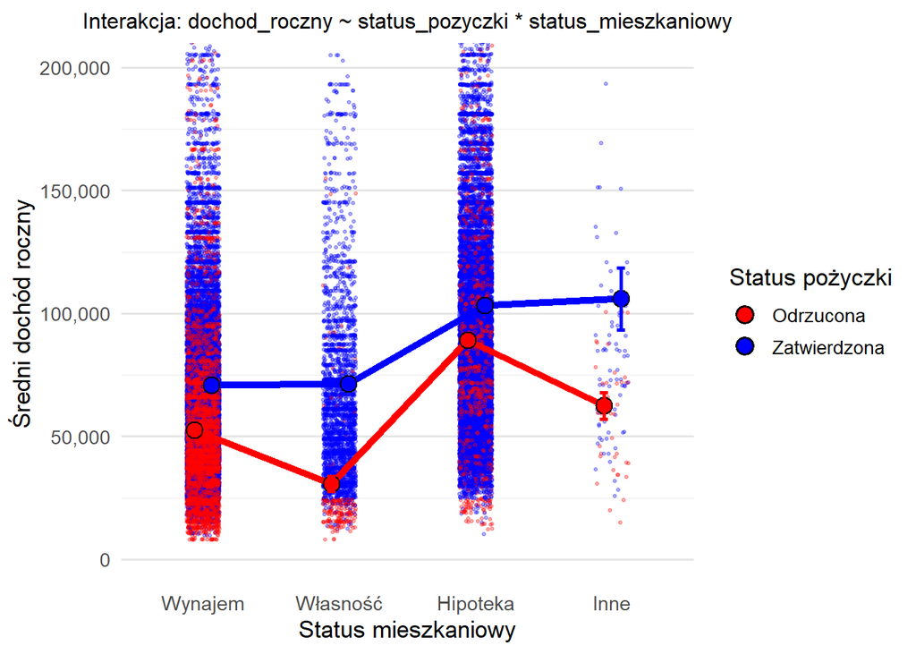

## 6.5 Test Kruskala-Wallisa - nieparametryczny test statystyczny służący do porównywania median

Wyniki testu Kruskala-Wallisa oraz post-hoc Dunn dla dochodu rocznego

| Test | Statystyka | p-value |
| --- | --- | --- |
| Kruskal-Wallis | H = 3402 | <0.001 |
| Dunn (0 vs 1) | Z = 58.33 | <0.001 |

Wybrane statystyki opisowe dochodu rocznego wg status_pozyczki

| Status pożyczki | N | Mediana | Kwartyl1 | Kwartyl3 | Przycięta średnia |
| --- | --- | --- | --- | --- | --- |
| 0 | 10000 | 50629 | 36841.75 | 71888.25 | 53704.32 |
| 1 | 35000 | 72928 | 51476.50 | 101994.00 | 76787.85 |

> Test Kruskal–Wallisa wykazał istotną różnicę w rozkładzie dochodu rocznego między grupami (χ² ≈ 3402.37, df = 1, p < 0.001). Post‑hoc Dunn potwierdza, że różnica dotyczy pary 0 vs 1 (stat ≈ 58.3, p_FDR < 0.001); z tabeli opisowej wynika, że grupa „Zatwierdzona” ma wyraźnie wyższe wartości dochodu (mediana ≈ 72 928, średnia ≈ 86 157) niż grupa „Odrzucona” (mediana ≈ 50 629, średnia ≈ 59 886).

## 6.6 Porównanie % pożyczki względem wcześniejszych zaległości

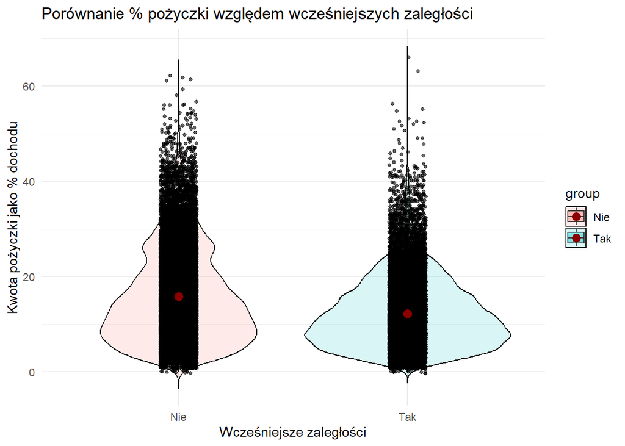

# 7 Podsumowanie i wnioski końcowe

Niniejszy raport poddał analizie zbiór **45 000 wniosków kredytowych.** Przeprowadzony został proces czyszczenia danych, imputacji braków metodą hot-deck oraz weryfikacji statystycznej.

## 7.1 Jakość danych i czyszczenie

Analiza wykazała obecność **licznych błędów logicznych** w danych surowych (np. wiek 144 lata, staż pracy 125 lat), co wymagało rygorystycznego czyszczenia.

**Rekomendacja:** Dla celów predykcyjnych w przyszłości, zaleca się budowę modelu regresji logistycznej w oparciu o zmienne: procent_dochodu_pozyczka, dochod_roczny oraz wczesniejsze_zaleglosci, gdyż wykazują one najwyższą moc dyskryminacyjną.

## 7.2 Kluczowe czynniki wpływające na decyzję kredytową

Najsilniejszymi czynnikami różnicującymi grupę pożyczek zatwierdzonych od odrzuconych okazały się wskaźniki ekonomiczne oraz historia kredytowa. Najważniejszym parametrem numerycznym okazała się **relacja pożyczki do dochodu.** Im wyższy udział wnioskowanej kwoty w rocznym dochodzie, tym gwałtowniej spada szansa na akceptację *(każdy wzrost o 1 p.p. udziału zmniejsza szanse na pożyczkę o ok. 10%).*

### 7.2.1 Cel pożyczki

Przeprowadzona analiza wykazała, że instytucje finansowe wykazują preferencje co do przeznaczenia środków. Najwyższy odsetek akceptacji odnotowano dla pożyczek o charakterze “inwestycyjnym” (Venture) oraz edukacyjnym. Najtrudniej o finansowanie w przypadku spłaty zadłużenia, remontów i wydatków medycznych.